# LAB 3 Dada2 Notebook

### Package installation

If you haven’t already, install the required software. The commands in this section are run only once and should be commented after you have finished running them

```r
# Installing Bioconductor

if (!requireNamespace("BiocManager", quietly = TRUE))
  install.packages("BiocManager")
BiocManager::install()

# Installing dada2
BiocManager::install("dada2")

# Installing other packages needed
install.packages("ggplot2")
install.packages("vegan")
```

### Unpacking and sorting files

The following commands can be run in a terminal window (Mac) or in Rstudio console window. The tar archive should be unpacked in a suitable location (i.e., not the desktop). Preferably you have a robust file naming system for your research. For example, my research analysis are all kept in ~/Documents/research/. Each project has the following subdirectories: data/, analysis, scripts/. Scripts contains the R project. Other directories can be added as needed (e.g., manuscript, reports, ppt, etc.). This compartmentalizes the projects and helps keep things organized.

#### Decompress the and untar the archive (Mac)

First navigate to where you are storing your data. The decompress it. On Windows you will probably need 7zip or WinZip to decompress and unpack.

```r
cd <path_to_data>
tar -xvf path_592_files_biogeo.tar.gz
```

### Set the environment

#### Load required libraries

```r
library(dada2)
library(ggplot2)
options(stringsAsFactors = F)
```

### Import data

```r
path <- "/Users/cgaulke/unsynced_projects/raw_data/2022_10_10_path592_raw/"

filt.path <- "/Users/cgaulke/Documents/research/path592/lab_2_QC/filtered_data/" #filtered file directory make sure to update
```

Make sure everything is looking OK

```r
head(list.files(path))
```

```
[1] "F10GD_032522_AACTTTCAGGAG_L001_R1_001.fastq.gz"
[2] "F10GD_032522_AACTTTCAGGAG_L001_R2_001.fastq.gz"
[3] "F10GM_032522_ACACACCCTGAC_L001_R1_001.fastq.gz"
[4] "F10GM_032522_ACACACCCTGAC_L001_R2_001.fastq.gz"
[5] "F10GP_032522_CGAATACTGACA_L001_R1_001.fastq.gz"
[6] "F10GP_032522_CGAATACTGACA_L001_R2_001.fastq.gz"
```

Now make sure that that we are only going to be working with fastq files

```r
fnFs <- sort(list.files(path, pattern="_R1_001.fastq.gz", full.names = TRUE))
fnRs <- sort(list.files(path, pattern="_R2_001.fastq.gz", full.names = TRUE))
```

### Quality Control

First we will make sure nothing has gone wrong by checking that the number of forward and reverse read files are the same.

```r
length(fnFs) == length(fnRs)
```

```
[1] TRUE
```

We might also want to make some new, easier to work with, sample names for later

```r
sample.names <- sapply(strsplit(basename(fnFs), "_R1"), `[`, 1)
```

#### Plotting quality scores using dada2

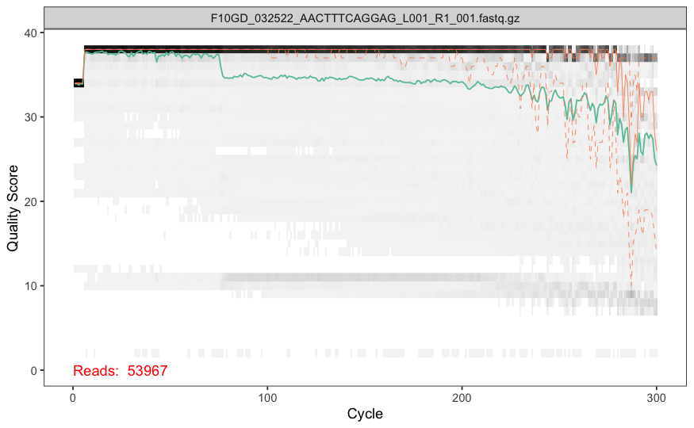

```r
plotQualityProfile(fnFs[1])
```

```
Warning: `guides(<scale> = FALSE)` is deprecated. Please use `guides(<scale> = "none")` instead.
```

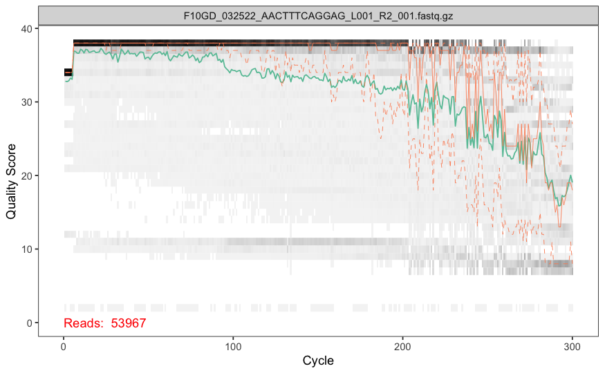

```r
plotQualityProfile(fnRs[1])
```

Warnings are generally OK, but should be read, errors on the otherhand usually need to be addressed.

Now we can plot all the read quality scores aggregated together (this might take a minute)

```r
fnFs_qual.plot <- plotQualityProfile(fnFs,aggregate = T)
```

```
Warning: `guides(<scale> = FALSE)` is deprecated. Please use `guides(<scale> = "none")` instead.
```

```r
fnRs_qual.plot <- plotQualityProfile(fnRs,aggregate = T)
```

While this is easier to look at than one plot at a time, it is still hard to see where the cutoffs should be. Since this is just wrapping ggplot2 code (see raw script), we can extend their code a bit

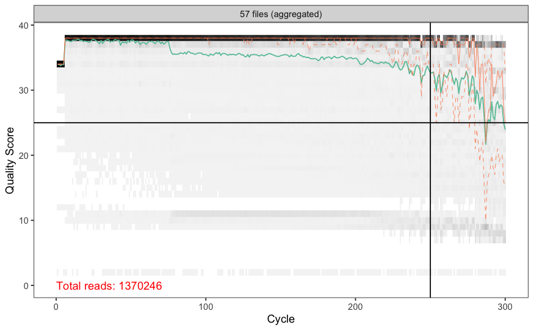

```r
fnFs_qual.plot + geom_hline(yintercept= 25) + geom_vline(xintercept = 250)
```

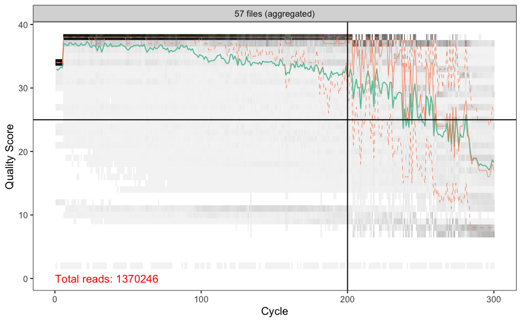

```r
fnRs_qual.plot + geom_hline(yintercept= 25) + geom_vline(xintercept = 200)
```

OK, so the reverse reads look a little worse than the forwards but the trimming thresholds (lines) wond eliminate overlap of the reads so we are OK.

#### Filtering reads

Next we want to set up names and locations for our filtered files that we will create later

```r
filtFs <- file.path(filt.path, "filtered",
                    paste0(sample.names, "_F_filt.fastq.gz"))

filtRs <- file.path(filt.path, "filtered",
                    paste0(sample.names, "_R_filt.fastq.gz"))
```

Next we will name them

```r
names(filtFs) <- sample.names
names(filtRs) <- sample.names
```

Looking at the data we see a rapid drop in quality around 250bp R1 (200 R2). Since the average drops below ~30 (99.9% accuracy) around 250 and approachs Q25 at 200 we will truncate at 200 for the reverse. The forward looks better (this is usual) so we will truncate around 250. We will also take off about 10 bases on the left as these bases are highly skewed (see multiqc).

```r
filter.out <- filterAndTrim(fnFs, #paths to the input forward reads
                            filtFs, #paths to the output filtered forward reads
                            fnRs, #paths to the input reverse reads
                            filtRs, #paths to the output filtered reverse reads
                            truncLen=c(250,200), #R1 and R2 truncation lengths
                            maxN=0, #max allowable N's (ambiguous bases) in seq
                            maxEE=c(2,2), # max error allowed after filtering
                            truncQ=2, # truncate at first base with this score
                            rm.phix=TRUE, # remove phix reads
                            trimLeft = 10, # number of nt to trim from left
                            compress=TRUE, # gzip files
                            multithread=TRUE # OK for Mac, turn off on Windows
                            )
```

Now Let’s check out the results

```r
head(filter.out)
```

```
                                               reads.in
F10GD_032522_AACTTTCAGGAG_L001_R1_001.fastq.gz    53967
F10GM_032522_ACACACCCTGAC_L001_R1_001.fastq.gz    10081
F10GP_032522_CGAATACTGACA_L001_R1_001.fastq.gz     4498
F10GS_032522_AACCGCATAAGT_L001_R1_001.fastq.gz    40118
F10SB_032522_AGATTCGCTCGA_L001_R1_001.fastq.gz    37212
F1GD_032122_AAGGCGCTCCTT_L001_R1_001.fastq.gz     35448
                                               reads.out
F10GD_032522_AACTTTCAGGAG_L001_R1_001.fastq.gz     43387
F10GM_032522_ACACACCCTGAC_L001_R1_001.fastq.gz      6760
F10GP_032522_CGAATACTGACA_L001_R1_001.fastq.gz      2678
F10GS_032522_AACCGCATAAGT_L001_R1_001.fastq.gz     21685
F10SB_032522_AGATTCGCTCGA_L001_R1_001.fastq.gz     31691
F1GD_032122_AAGGCGCTCCTT_L001_R1_001.fastq.gz      32505
```

```r
colMeans(filter.out) #mean number of reads in and out of filtering
```

```
 reads.in reads.out
 24039.40  19921.68
```

```r
mean(1-(filter.out[,2]/filter.out[,1])) #mean % filtered reads
```

```
[1] 0.1863549
```

We can also dive into these numbers a little deeper

```r
fivenum(1-(filter.out[,2]/filter.out[,1])) #five number report for % filtered
```

```
F8GD_032522_CGGCCAGAAGCA_L001_R1_001.fastq.gz
                                   0.05710446
F1GM_032122_CGCGCAAGTATT_L001_R1_001.fastq.gz
                                   0.08961702
F1GP_032122_CCTCGCATGACC_L001_R1_001.fastq.gz
                                   0.14078695
F3GM_032122_ACTAAGTACCCG_L001_R1_001.fastq.gz
                                   0.21935123
F3SS_032122_GGACAAGTGCGA_L001_R1_001.fastq.gz
                                   0.62975414
```

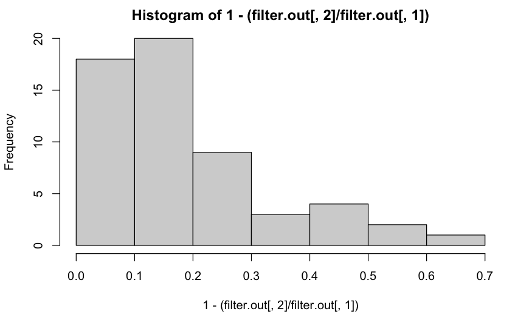

```r
hist(1-(filter.out[,2]/filter.out[,1]))  # hist #mean % filtered reads
```

Since some libraries look like there is a higher level of filtration than others lets take a closer look at which ones are not great.

```r
tail(sort(
  1-(filter.out[,2]/filter.out[,1])
  ),  n =10
)
```

```
 F9SB_032522_AAGTCACACACA_L001_R1_001.fastq.gz
                                     0.3204055
 F4SB_032322_CACCCTTGCGAC_L001_R1_001.fastq.gz
                                     0.3212244
F10GM_032522_ACACACCCTGAC_L001_R1_001.fastq.gz
                                     0.3294316
F10GP_032522_CGAATACTGACA_L001_R1_001.fastq.gz
                                     0.4046243
 F3SB_032122_GTTAACTTACTA_L001_R1_001.fastq.gz
                                     0.4278786
 F4SS_032322_GTTGTTCTGGGA_L001_R1_001.fastq.gz
                                     0.4426796
F10GS_032522_AACCGCATAAGT_L001_R1_001.fastq.gz
                                     0.4594696
 F4GP_032122_CTGATGTACACG_L001_R1_001.fastq.gz
                                     0.5119294
 F3GS_032122_GCGAGGAAGTCC_L001_R1_001.fastq.gz
                                     0.5971425
 F3SS_032122_GGACAAGTGCGA_L001_R1_001.fastq.gz
                                     0.6297541
```

### Sequence error analysis

The core Dada2 algorithm requires that we understand the error rates of the specific sequence reads our data set.

```r
errF <- learnErrors(filtFs, multithread=TRUE)
```

```
102603360 total bases in 427514 reads from 19 samples will be used for learning the error rates.
```

```r
errR <- learnErrors(filtRs, multithread=TRUE)
```

```
105850330 total bases in 557107 reads from 27 samples will be used for learning the error rates.
```

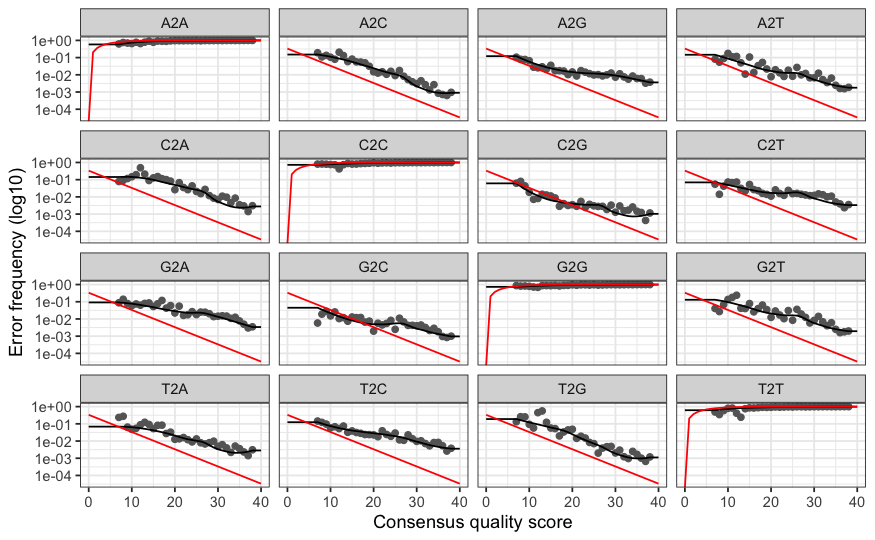

```r
plotErrors(errF, nominalQ=TRUE)
```

Now we can use these data to denoise our reads.

```r
dadaFs <- dada(filtFs, err=errF, multithread=TRUE)
```

```
Sample 1 - 43387 reads in 10931 unique sequences.
Sample 2 - 6760 reads in 2887 unique sequences.
Sample 3 - 2678 reads in 1138 unique sequences.
Sample 4 - 21685 reads in 6753 unique sequences.
Sample 5 - 31691 reads in 9109 unique sequences.
Sample 6 - 32505 reads in 9789 unique sequences.
Sample 7 - 27479 reads in 10720 unique sequences.
Sample 8 - 26029 reads in 10637 unique sequences.
Sample 9 - 3885 reads in 1978 unique sequences.
Sample 10 - 5827 reads in 2381 unique sequences.
Sample 11 - 12324 reads in 5510 unique sequences.
Sample 12 - 38471 reads in 7066 unique sequences.
Sample 13 - 31820 reads in 11164 unique sequences.
Sample 14 - 5007 reads in 1887 unique sequences.
Sample 15 - 15132 reads in 5927 unique sequences.
Sample 16 - 7690 reads in 3450 unique sequences.
Sample 17 - 24951 reads in 4000 unique sequences.
Sample 18 - 41874 reads in 8511 unique sequences.
Sample 19 - 48319 reads in 14167 unique sequences.
Sample 20 - 5893 reads in 1912 unique sequences.
Sample 21 - 8258 reads in 3505 unique sequences.
Sample 22 - 7379 reads in 3312 unique sequences.
Sample 23 - 50916 reads in 10401 unique sequences.
Sample 24 - 16506 reads in 6002 unique sequences.
Sample 25 - 9185 reads in 2931 unique sequences.
Sample 26 - 233 reads in 149 unique sequences.
Sample 27 - 31223 reads in 10033 unique sequences.
Sample 28 - 9193 reads in 3896 unique sequences.
Sample 29 - 44344 reads in 7002 unique sequences.
Sample 30 - 39034 reads in 7737 unique sequences.
Sample 31 - 21350 reads in 6334 unique sequences.
Sample 32 - 8816 reads in 2598 unique sequences.
Sample 33 - 4185 reads in 1421 unique sequences.
Sample 34 - 6808 reads in 2620 unique sequences.
Sample 35 - 7340 reads in 2927 unique sequences.
Sample 36 - 29576 reads in 4661 unique sequences.
Sample 37 - 9216 reads in 3362 unique sequences.
Sample 38 - 8896 reads in 3470 unique sequences.
Sample 39 - 5513 reads in 2262 unique sequences.
Sample 40 - 10114 reads in 3862 unique sequences.
Sample 41 - 13531 reads in 4282 unique sequences.
Sample 42 - 45276 reads in 7167 unique sequences.
Sample 43 - 39138 reads in 10255 unique sequences.
Sample 44 - 4538 reads in 1664 unique sequences.
Sample 45 - 24797 reads in 7756 unique sequences.
Sample 46 - 1651 reads in 488 unique sequences.
Sample 47 - 44202 reads in 7668 unique sequences.
Sample 48 - 43884 reads in 15245 unique sequences.
Sample 49 - 19243 reads in 6252 unique sequences.
Sample 50 - 6870 reads in 2791 unique sequences.
Sample 51 - 2447 reads in 912 unique sequences.
Sample 52 - 13082 reads in 4500 unique sequences.
Sample 53 - 45884 reads in 13822 unique sequences.
Sample 54 - 38479 reads in 9658 unique sequences.
Sample 55 - 12314 reads in 3938 unique sequences.
Sample 56 - 1542 reads in 650 unique sequences.
Sample 57 - 17166 reads in 5824 unique sequences.
```

```r
dadaRs <- dada(filtRs, err=errR, multithread=TRUE)
```

```
Sample 1 - 43387 reads in 10537 unique sequences.
Sample 2 - 6760 reads in 2774 unique sequences.
Sample 3 - 2678 reads in 1084 unique sequences.
Sample 4 - 21685 reads in 7032 unique sequences.
Sample 5 - 31691 reads in 9164 unique sequences.
Sample 6 - 32505 reads in 8889 unique sequences.
Sample 7 - 27479 reads in 10055 unique sequences.
Sample 8 - 26029 reads in 8754 unique sequences.
Sample 9 - 3885 reads in 1647 unique sequences.
Sample 10 - 5827 reads in 2309 unique sequences.
Sample 11 - 12324 reads in 4558 unique sequences.
Sample 12 - 38471 reads in 7199 unique sequences.
Sample 13 - 31820 reads in 10835 unique sequences.
Sample 14 - 5007 reads in 1880 unique sequences.
Sample 15 - 15132 reads in 5404 unique sequences.
Sample 16 - 7690 reads in 3026 unique sequences.
Sample 17 - 24951 reads in 4193 unique sequences.
Sample 18 - 41874 reads in 7814 unique sequences.
Sample 19 - 48319 reads in 13334 unique sequences.
Sample 20 - 5893 reads in 1875 unique sequences.
Sample 21 - 8258 reads in 3071 unique sequences.
Sample 22 - 7379 reads in 2643 unique sequences.
Sample 23 - 50916 reads in 10150 unique sequences.
Sample 24 - 16506 reads in 6005 unique sequences.
Sample 25 - 9185 reads in 2935 unique sequences.
Sample 26 - 233 reads in 148 unique sequences.
Sample 27 - 31223 reads in 9574 unique sequences.
Sample 28 - 9193 reads in 3619 unique sequences.
Sample 29 - 44344 reads in 7015 unique sequences.
Sample 30 - 39034 reads in 7979 unique sequences.
Sample 31 - 21350 reads in 5711 unique sequences.
Sample 32 - 8816 reads in 2748 unique sequences.
Sample 33 - 4185 reads in 1491 unique sequences.
Sample 34 - 6808 reads in 2589 unique sequences.
Sample 35 - 7340 reads in 2835 unique sequences.
Sample 36 - 29576 reads in 4588 unique sequences.
Sample 37 - 9216 reads in 3020 unique sequences.
Sample 38 - 8896 reads in 3389 unique sequences.
Sample 39 - 5513 reads in 2214 unique sequences.
Sample 40 - 10114 reads in 3794 unique sequences.
Sample 41 - 13531 reads in 4313 unique sequences.
Sample 42 - 45276 reads in 7077 unique sequences.
Sample 43 - 39138 reads in 9746 unique sequences.
Sample 44 - 4538 reads in 1642 unique sequences.
Sample 45 - 24797 reads in 7279 unique sequences.
Sample 46 - 1651 reads in 487 unique sequences.
Sample 47 - 44202 reads in 7559 unique sequences.
Sample 48 - 43884 reads in 14590 unique sequences.
Sample 49 - 19243 reads in 6347 unique sequences.
Sample 50 - 6870 reads in 2672 unique sequences.
Sample 51 - 2447 reads in 945 unique sequences.
Sample 52 - 13082 reads in 4416 unique sequences.
Sample 53 - 45884 reads in 13277 unique sequences.
Sample 54 - 38479 reads in 9278 unique sequences.
Sample 55 - 12314 reads in 3709 unique sequences.
Sample 56 - 1542 reads in 702 unique sequences.
Sample 57 - 17166 reads in 5822 unique sequences.
```

### Merge and Filter reads

Next we will merge our forward and reverse reads into one contig. We will also filter PCR artifacts called chimeras (Bimeras)

```r
mergers <- mergePairs(dadaFs, filtFs, dadaRs, filtRs, verbose=TRUE)

#Make a table of samples x asvs
seqtab <- makeSequenceTable(mergers)
dim(seqtab)
```

```
[1]   57 2034
```

```r
#remove chimeras
seqtab.nochim <- removeBimeraDenovo(seqtab, method="consensus",
                                    multithread=TRUE,
                                    verbose=TRUE)

dim(seqtab.nochim)
```

```
[1]   57 1817
```

In some libraries chimeras can make up a large portion of ASVs, so we should always quantify our lose

```r
sum(seqtab.nochim)/sum(seqtab)
```

```
[1] 0.9905017
```

Now we need to export these data so we can access them later.

```r
write.table(seqtab.nochim,
            file = "../out_files/seqtab_nochim.txt",
            quote = FALSE,
            sep = "\t",
            )
```

### Track reads

```r
getN <- function(x) sum(getUniques(x))
track <- cbind(filter.out, sapply(dadaFs, getN),
               sapply(dadaRs, getN),
               sapply(mergers, getN),
               rowSums(seqtab.nochim))
colnames(track) <- c("input", "filtered", "denoisedF", "denoisedR", "merged", "nonchim")
rownames(track) <- sample.names
head(track)
```

```
                               input filtered denoisedF
F10GD_032522_AACTTTCAGGAG_L001 53967    43387     42887
F10GM_032522_ACACACCCTGAC_L001 10081     6760      6659
F10GP_032522_CGAATACTGACA_L001  4498     2678      2625
F10GS_032522_AACCGCATAAGT_L001 40118    21685     21026
F10SB_032522_AGATTCGCTCGA_L001 37212    31691     31005
F1GD_032122_AAGGCGCTCCTT_L001  35448    32505     32342
                               denoisedR merged nonchim
F10GD_032522_AACTTTCAGGAG_L001     43240  41726   41553
F10GM_032522_ACACACCCTGAC_L001      6704   6159    5995
F10GP_032522_CGAATACTGACA_L001      2619   2362    2362
F10GS_032522_AACCGCATAAGT_L001     21579  19272   19089
F10SB_032522_AGATTCGCTCGA_L001     31477  30443   30003
F1GD_032122_AAGGCGCTCCTT_L001      32336  30452   30248
```

### Add Taxonomy

Here is where you will need to go and download the silva databases.Be sure to get the right ones (the names are the same as the ones below) These files can be downloaded here: https://zenodo.org/record/4587955#.YSlzKC1h1hA

```r
taxa <- assignTaxonomy(seqtab.nochim,
          "/Users/cgaulke/unsynced_projects/db/silva_dada2/silva_nr99_v138.1_train_set.fa",
          multithread=TRUE)

#note species assignment is probably not super accurate
taxa <- addSpecies(taxa, "/Users/cgaulke/unsynced_projects/db/silva_dada2/silva_species_assignment_v138.1.fa")

taxa.print <- taxa
rownames(taxa.print) <- NULL
head(taxa.print)
```

```
     Kingdom     Phylum              Class
[1,] "Bacteria"  "Proteobacteria"    "Gammaproteobacteria"
[2,] "Bacteria"  "Firmicutes"        "Bacilli"
[3,] "Eukaryota" NA                  NA
[4,] "Bacteria"  "Verrucomicrobiota" "Verrucomicrobiae"
[5,] "Bacteria"  "Bacteroidota"      "Bacteroidia"
[6,] "Bacteria"  "Firmicutes"        "Bacilli"
     Order                Family
[1,] "Enterobacterales"   "Aeromonadaceae"
[2,] "Erysipelotrichales" "Erysipelotrichaceae"
[3,] NA                   NA
[4,] "Verrucomicrobiales" "Akkermansiaceae"
[5,] "Bacteroidales"      "Bacteroidaceae"
[6,] "Erysipelotrichales" "Erysipelotrichaceae"
     Genus         Species
[1,] "Aeromonas"   NA
[2,] "Dubosiella"  "newyorkensis"
[3,] NA            NA
[4,] "Akkermansia" "muciniphila"
[5,] "Bacteroides" NA
[6,] "ZOR0006"     NA
```

```r
head(taxa)
```

[output not shown]

[output cut: 28 more lines]

```r
#now we can write this file out

write.table(taxa.print,
            file = "../out_files/taxa.txt",
            quote = FALSE,
            sep = "\t",
            )
```